# Naive Bayes and Single-Layer Neural Network

We are going to try and see how accurately these two classifiers can predict fare price for our taxi rides. We have our data labeled with a binning system.

```python
import warnings
warnings.simplefilter("ignore")

import pandas as pd
import matplotlib as plt
import numpy as np
import sklearn as sk

from sklearn.preprocessing import StandardScaler
from sklearn.pipeline import Pipeline
from sklearn.naive_bayes import GaussianNB
from sklearn.model_selection import cross_val_score
from sklearn.model_selection import cross_val_predict
from sklearn.metrics import confusion_matrix
from sklearn.metrics import classification_report
from sklearn.model_selection import GridSearchCV
from sklearn.neural_network import MLPClassifier
```

```python
#import data
data = pd.read_csv("taxi_clean_lg.csv")

#display data
print(data.shape)

data.head()
```

```
(80501, 19)
```

|  | trip_distance | fare_amount | winter | spring | summer | fall | PULongitude | PULatitude | DOLongitude | DOLatitude | pickup_datetime | dropoff_datetime | ride_duration | Early morning | Morning | Afternoon | Night | Holiday Proximity | label |
| --- | --- | --- | --- | --- | --- | --- | --- | --- | --- | --- | --- | --- | --- | --- | --- | --- | --- | --- | --- |
| 0 | 5.90 | 41.5 | 0 | 1 | 0 | 0 | -73.984176 | 40.759845 | -73.961815 | 40.809570 | 2019-03-26 14:24:29 | 2019-03-26 15:26:27 | 0 days 01:01:58.000000000 | 0 | 0 | 1 | 0 | 1 | J |
| 1 | 7.31 | 28.0 | 0 | 0 | 1 | 0 | -73.965572 | 40.782460 | -73.853384 | 40.752316 | 2019-07-03 07:15:18 | 2019-07-03 07:49:08 | 0 days 00:33:50.000000000 | 0 | 1 | 0 | 0 | 0 | J |
| 2 | 0.99 | 5.5 | 0 | 1 | 0 | 0 | -73.981352 | 40.773906 | -73.987973 | 40.775770 | 2019-05-25 17:25:49 | 2019-05-25 17:30:21 | 0 days 00:04:32.000000000 | 0 | 0 | 1 | 0 | 0 | B |
| 3 | 1.91 | 9.0 | 0 | 0 | 1 | 0 | -73.972145 | 40.756816 | -73.956972 | 40.780491 | 2019-07-22 15:31:00 | 2019-07-22 15:41:36 | 0 days 00:10:36.000000000 | 0 | 0 | 1 | 0 | 0 | C |
| 4 | 1.18 | 7.5 | 0 | 1 | 0 | 0 | -73.965691 | 40.768542 | -73.954568 | 40.765507 | 2019-03-13 21:13:28 | 2019-03-13 21:21:42 | 0 days 00:08:14.000000000 | 0 | 0 | 0 | 0 | 0 | C |

When converting our cleaned data into a csv and then loading it back into this notebook, we lose the datetime format for our pickup and drop off times.  
Here we will transform it into a numeric object so our algorithms will run smoothly.

```python
data['pickup_datetime'] = pd.to_datetime(data['pickup_datetime'])
data['pickup_datetime'] = pd.to_numeric(data['pickup_datetime'])
data['dropoff_datetime'] = pd.to_datetime(data['dropoff_datetime'])
data['dropoff_datetime'] = pd.to_numeric(data['dropoff_datetime'])

data['ride_duration'] = data['dropoff_datetime'] - data['pickup_datetime']
```

### Splitting the data

```python
#split our data
#data_X = our attributes
#data_y = labels

data_X = data.drop(['label'], axis = 1)
data_y = data['label']
```

### Naive Bayes Classification

```python
#start with naive bayes
#define our classifier
clf = GaussianNB()

#run a cross validation loop on our data and return the accuracy
scores = cross_val_score(clf, data_X, data_y, cv = 10)
print('Accuracy:',scores.mean()*100)
```

```
Accuracy: 53.74845438552749
```

```python
#display results with a confusion matrix
y_pred = cross_val_predict( clf, data_X, data_y, cv = 10)
y_pred

print('Confusion Matrix:\n', confusion_matrix(data_y , y_pred),'\n')
print("Classification Report:\n\n", classification_report(data_y, y_pred))
```

```
Confusion Matrix:
 [[    0  5869     2     0     0     0     0     0     0     0]
 [    0 18843   295     2     1     0     0     0     0     1]
 [    0  5275 11339    46     5     1     0     0     0     2]
 [    0   259  7141  3987    28     2     0     0     0     2]
 [    0    45  1338  4049  1850    19     0     0     0     1]
 [    0    11   408  1310  2042   818     0     0     0    88]
 [    0     7   183   605   904   731     0     0     0   760]
 [    0     0    98   352   497   426     0     0     0   861]
 [    0     0    53   247   306   248     0     0     0   760]
 [    0    11    34   292   790   826     0     0     0  6431]]

Classification Report:

               precision    recall  f1-score   support

           A       0.00      0.00      0.00      5871
           B       0.62      0.98      0.76     19142
           C       0.54      0.68      0.60     16668
           D       0.37      0.35      0.36     11419
           E       0.29      0.25      0.27      7302
           F       0.27      0.17      0.21      4677
           G       0.00      0.00      0.00      3190
           H       0.00      0.00      0.00      2234
           I       0.00      0.00      0.00      1614
           J       0.72      0.77      0.74      8384

    accuracy                           0.54     80501
   macro avg       0.28      0.32      0.29     80501
weighted avg       0.43      0.54      0.47     80501
```

### Single-Layer Neural Network Classifier

```python
#we will test 50, 75, and 100 nodes in each layer
layers = [ (50,), (75,), (100,)]
```

```python
scaler = StandardScaler()

#create classifier object
mlp = MLPClassifier()

#create pipeline
pipe = Pipeline(steps = [('scaler',scaler),('MLP',mlp)])

#define parameters
param_grid = { 'MLP__hidden_layer_sizes' : layers ,
              'MLP__activation' : ['logistic','tanh', 'relu']}

#create grid search object
grid_search = GridSearchCV(pipe, param_grid, cv = 3)

#calculate score
score = cross_val_score(grid_search, data_X, data_y, cv = 3)

#print results
print('Average Accuracy:',score.mean())
```

```
Average Accuracy: 0.9996646194179823
```

```python
#now that we know our average accuracy, we will fit our grid search to find the best parameters
grid_search.fit(data_X, data_y)
```

```
GridSearchCV(cv=3, error_score='raise-deprecating',
             estimator=Pipeline(memory=None,
                                steps=[('scaler',
                                        StandardScaler(copy=True,
                                                       with_mean=True,
                                                       with_std=True)),
                                       ('MLP',
                                        MLPClassifier(activation='relu',
                                                      alpha=0.0001,
                                                      batch_size='auto',
                                                      beta_1=0.9, beta_2=0.999,
                                                      early_stopping=False,
                                                      epsilon=1e-08,
                                                      hidden_layer_sizes=(100,),
                                                      learning_rate='constant',
                                                      learning_rate_in...
                                                      power_t=0.5,
                                                      random_state=None,
                                                      shuffle=True,
                                                      solver='adam', tol=0.0001,
                                                      validation_fraction=0.1,
                                                      verbose=False,
                                                      warm_start=False))],
                                verbose=False),
             iid='warn', n_jobs=None,
             param_grid={'MLP__activation': ['logistic', 'tanh', 'relu'],
                         'MLP__hidden_layer_sizes': [(50,), (75,), (100,)]},
             pre_dispatch='2*n_jobs', refit=True, return_train_score=False,
             scoring=None, verbose=0)
```

```python
#display our results from our grid search
print(grid_search.best_score_)
print(grid_search.best_params_)
```

```
0.9998385113228407
{'MLP__activation': 'logistic', 'MLP__hidden_layer_sizes': (100,)}
```

```python
#display results with a confusion matrix
mlp = MLPClassifier( hidden_layer_sizes = (100,), activation = 'logistic')
y_pred = cross_val_predict( mlp, data_X, data_y, cv = 5)
y_pred

print('Confusion Matrix:\n', confusion_matrix(data_y , y_pred),'\n')
print("Classification Report:\n\n", classification_report(data_y, y_pred))
```

```
Confusion Matrix:
 [[    0  5871     0     0     0     0     0     0     0     0]
 [    0 19142     0     0     0     0     0     0     0     0]
 [    0 16668     0     0     0     0     0     0     0     0]
 [    0 11419     0     0     0     0     0     0     0     0]
 [    0  7302     0     0     0     0     0     0     0     0]
 [    0  4677     0     0     0     0     0     0     0     0]
 [    0  3190     0     0     0     0     0     0     0     0]
 [    0  2234     0     0     0     0     0     0     0     0]
 [    0  1614     0     0     0     0     0     0     0     0]
 [    0  8384     0     0     0     0     0     0     0     0]]

Classification Report:

               precision    recall  f1-score   support

           A       0.00      0.00      0.00      5871
           B       0.24      1.00      0.38     19142
           C       0.00      0.00      0.00     16668
           D       0.00      0.00      0.00     11419
           E       0.00      0.00      0.00      7302
           F       0.00      0.00      0.00      4677
           G       0.00      0.00      0.00      3190
           H       0.00      0.00      0.00      2234
           I       0.00      0.00      0.00      1614
           J       0.00      0.00      0.00      8384

    accuracy                           0.24     80501
   macro avg       0.02      0.10      0.04     80501
weighted avg       0.06      0.24      0.09     80501
```

# Results:

### 2. Neural Network (one layer)

We first see that we have an accuracy of 99% for our MLP classifier. When looking more closely, we see that all of the "B" class is getting classified correctly. However, it seems that everything else is getting classified as B as well.

This would not be a good model to use, because every ride will be classified the same, which will result in many errors for more expensive rides. In a real application, people may have their fare predicted at a class 'B' price, but later be charged a much higher fare which would not be good for the company.

Below we can see that 'B' is the most common class label in our data set, but class label 'C' is not far behind. In our Neural Net, label 'C' had 0.00 recall and 0.00 precision, but in Naive Bayes, class label 'C' looked better with 0.54 precision and 0.68 recall.

While there is a class imbalance, the difference in value counts for the classes are not drastic enough to overlook the low precision.

Overall, these two classifiers are not accurate enough to practically use to predict fare values.

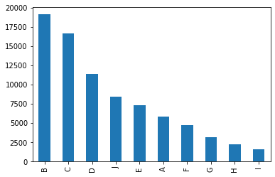

```python
#display frequency of different classes
data_classes = data['label'].value_counts()
data_classes.plot( kind='bar')
```